# QMSS G5072 Homework 1

Wenjun Sun

2019-09-17

# Using Github and RMarkdown

## R Markdown

### 1. Create R Markdown notebook html document

### 2. Get some data

I am interested in the data set named ‘bad_drivers’, which contains data about fatal traffic collisions in 51 states. The data set has 51 rows representing the states and 8 variables. Here is the story that the data was used for [Dear Mona, Which State Has The Worst Drivers?](https://fivethirtyeight.com/features/which-state-has-the-worst-drivers/).

| variable name | variable description |
| --- | --- |
| state | State |
| num_drivers | Number of drivers involved in fatal collisions per billion miles |
| perc_speeding | Percentage of drivers involved in fatal collisions who were speeding |
| perc_alcohol | Percentage of drivers involved in fatal collisions who were alcohol-impaired |
| perc_not_distracted | Percentage of drivers involved in fatal collisions who were not distracted |
| perc_no_previous | Percentage of drivers involved in fatal collisions who had not been involved in any previous accidents |
| insurance_premiums | Car insurance premiums ($) |
| losses | Losses incurred by insurance companies for collisions per insured driver ($) |

### 3. Show the data

#### A summary of the data

```
##     state            num_drivers    perc_speeding    perc_alcohol
##  Length:51          Min.   : 5.90   Min.   :13.00   Min.   :16.00
##  Class :character   1st Qu.:12.75   1st Qu.:23.00   1st Qu.:28.00
##  Mode  :character   Median :15.60   Median :34.00   Median :30.00
##                     Mean   :15.79   Mean   :31.73   Mean   :30.69
##                     3rd Qu.:18.50   3rd Qu.:38.00   3rd Qu.:33.00
##                     Max.   :23.90   Max.   :54.00   Max.   :44.00
##  perc_not_distracted perc_no_previous insurance_premiums     losses
##  Min.   : 10.00      Min.   : 76.00   Min.   : 642.0     Min.   : 82.75
##  1st Qu.: 83.00      1st Qu.: 83.50   1st Qu.: 768.4     1st Qu.:114.64
##  Median : 88.00      Median : 88.00   Median : 859.0     Median :136.05
##  Mean   : 85.92      Mean   : 88.73   Mean   : 887.0     Mean   :134.49
##  3rd Qu.: 95.00      3rd Qu.: 95.00   3rd Qu.:1007.9     3rd Qu.:151.87
##  Max.   :100.00      Max.   :100.00   Max.   :1301.5     Max.   :194.78
```

#### An interactive table of the data

|  | state | num_drivers | perc_speeding | perc_alcohol | perc_not_distracted | perc_no_previous | insurance_premiums | losses |
| --- | --- | --- | --- | --- | --- | --- | --- | --- |
| 1 | Alabama | 18.8 | 39 | 30 | 96 | 80 | 784.55 | 145.08 |
| 2 | Alaska | 18.1 | 41 | 25 | 90 | 94 | 1053.48 | 133.93 |
| 3 | Arizona | 18.6 | 35 | 28 | 84 | 96 | 899.47 | 110.35 |
| 4 | Arkansas | 22.4 | 18 | 26 | 94 | 95 | 827.34 | 142.39 |
| 5 | California | 12 | 35 | 28 | 91 | 89 | 878.41 | 165.63 |
| 6 | Colorado | 13.6 | 37 | 28 | 79 | 95 | 835.5 | 139.91 |
| 7 | Connecticut | 10.8 | 46 | 36 | 87 | 82 | 1068.73 | 167.02 |
| 8 | Delaware | 16.2 | 38 | 30 | 87 | 99 | 1137.87 | 151.48 |
| 9 | District of Columbia | 5.9 | 34 | 27 | 100 | 100 | 1273.89 | 136.05 |
| 10 | Florida | 17.9 | 21 | 29 | 92 | 94 | 1160.13 | 144.18 |

[output cut: 41 more lines]

#### A table created via ‘kable’

Data used in ‘Dear Mona, Which State Has The Worst Drivers?’

| state | num_drivers | perc_speeding | perc_alcohol | perc_not_distracted | perc_no_previous | insurance_premiums | losses |
| --- | --- | --- | --- | --- | --- | --- | --- |
| Alabama | 18.8 | 39 | 30 | 96 | 80 | 784.55 | 145.08 |
| Alaska | 18.1 | 41 | 25 | 90 | 94 | 1053.48 | 133.93 |
| Arizona | 18.6 | 35 | 28 | 84 | 96 | 899.47 | 110.35 |
| Arkansas | 22.4 | 18 | 26 | 94 | 95 | 827.34 | 142.39 |
| California | 12.0 | 35 | 28 | 91 | 89 | 878.41 | 165.63 |
| Colorado | 13.6 | 37 | 28 | 79 | 95 | 835.50 | 139.91 |

### 4. Add some Latex formulas

The model shows the linear association between car insurance premiums (dependant variable) and driver factors (independant variables) on state level, where driver factors include number of drivers involved in fatal collisions per billion miles $num\_drivers$, percentage of drivers involved in fatal collisions who were speeding $perc\_speeding$, and percentage of drivers involved in fatal collisions who were alcohol-impaired $perc\_alcohol$.

$$insurance\_premiums = \beta_0 + \beta_1num\_drivers + \beta_2perc\_speeding + \beta_3perc\_alcohol + \epsilon$$

### 5. Add a plot

This is a scatter plot showing the relationship between Car insurance premiums ($) and number of drivers involved in fatal collisions per billion miles of each state.

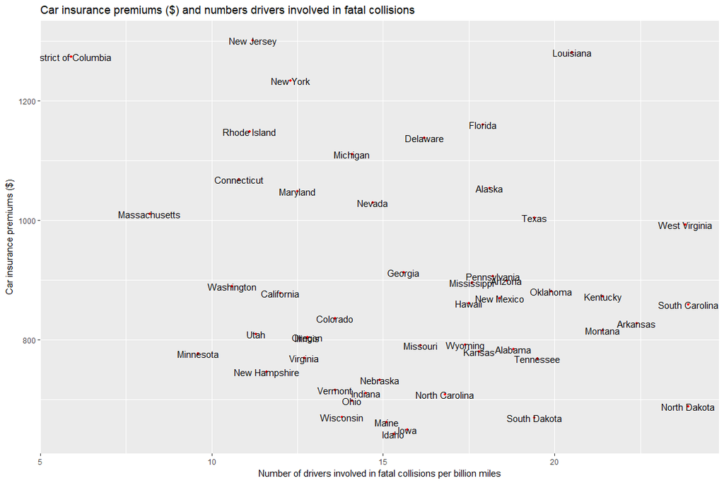

### 6. Add a picture

Here is a picture of Ryan Reynolds in ‘6 Underground’ that I found from [his tweet](https://twitter.com/vancityreynolds/status/1042486967148142592?lang=en).

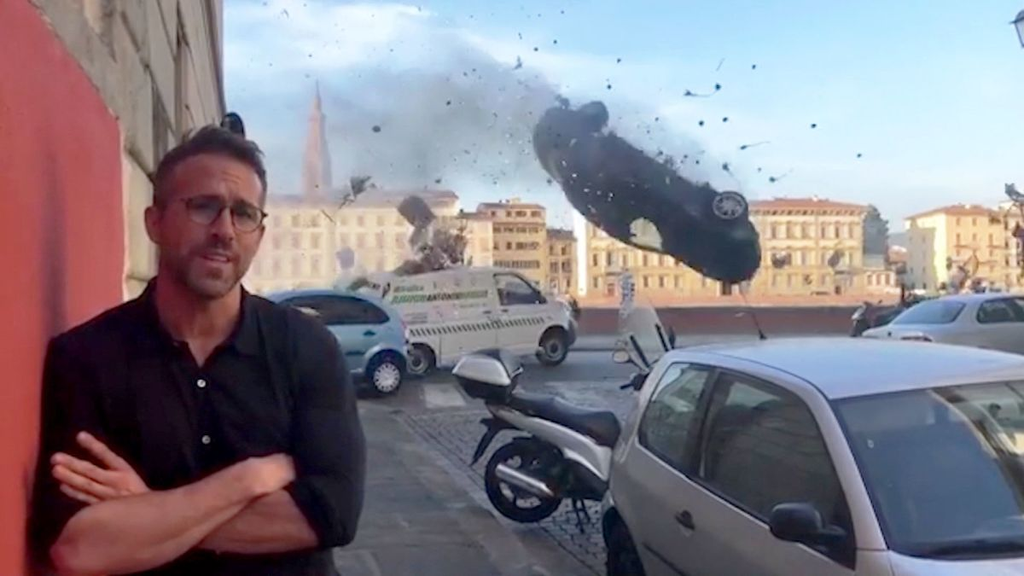

Too cool to have a crash

### 7. More Markdown

Here I used the R Markdown quick reference to make a footnote [^1] and a block quote.

> Here is the block quote.
[^1]: Here is the footnote.